# Module_6_Lab

Satya Allumallu

4/08/2022

### Non-Linear Classifiers and Tree based Classifiers

In this lab session we will build nonlinear classification models. We will apply mixture discriminant analysis, single hidden layer neural networks, support vector machines, k-nearest neighbors and tree based methods such as random forests and boosting to the wisconsin breast cancer data set. Data set at https://archive.ics.uci.edu/ml/datasets/breast+cancer+wisconsin+(diagnostic). In the end we will compare the performance of these models on the breast cancer data set.

```r
cnames <- c('Id', 'Clump_thickness', 'Uniformity_cell_size', 'Uniformity_cell_shape',
            'Marginal_adhesion', 'Single_e_cell_size', 'Bare_nuclei',
            'Bland_chromatin', 'Normal_nucleoli', 'Mitoses', 'Class')
bcancerdata <- read.csv('breast-cancer-wisconsin.data', header = FALSE,
                             col.names = cnames)
bcancerdata$Bare_nuclei <- as.numeric(as.character(bcancerdata$Bare_nuclei))
bcancerdata$Class <- ifelse(bcancerdata$Class == 4, "malignant", "benign")
bcancerdata$Class <- as.factor(bcancerdata$Class)
table(bcancerdata$Class)
```

```
##
##    benign malignant
##       458       241
```

```r
str(bcancerdata)
```

```
## 'data.frame':    699 obs. of  11 variables:
##  $ Id                   : int  1000025 1002945 1015425 1016277 1017023 1017122 1018099 1018561 1033078 1033078 ...
##  $ Clump_thickness      : int  5 5 3 6 4 8 1 2 2 4 ...
##  $ Uniformity_cell_size : int  1 4 1 8 1 10 1 1 1 2 ...
##  $ Uniformity_cell_shape: int  1 4 1 8 1 10 1 2 1 1 ...
##  $ Marginal_adhesion    : int  1 5 1 1 3 8 1 1 1 1 ...
##  $ Single_e_cell_size   : int  2 7 2 3 2 7 2 2 2 2 ...
##  $ Bare_nuclei          : num  1 10 2 4 1 10 10 1 1 1 ...
##  $ Bland_chromatin      : int  3 3 3 3 3 9 3 3 1 2 ...
##  $ Normal_nucleoli      : int  1 2 1 7 1 7 1 1 1 1 ...
##  $ Mitoses              : int  1 1 1 1 1 1 1 1 5 1 ...
##  $ Class                : Factor w/ 2 levels "benign","malignant": 1 1 1 1 1 2 1 1 1 1 ...
```

```r
summary(bcancerdata)
```

```
##        Id           Clump_thickness  Uniformity_cell_size Uniformity_cell_shape
##  Min.   :   61634   Min.   : 1.000   Min.   : 1.000       Min.   : 1.000
##  1st Qu.:  870688   1st Qu.: 2.000   1st Qu.: 1.000       1st Qu.: 1.000
##  Median : 1171710   Median : 4.000   Median : 1.000       Median : 1.000
##  Mean   : 1071704   Mean   : 4.418   Mean   : 3.134       Mean   : 3.207
##  3rd Qu.: 1238298   3rd Qu.: 6.000   3rd Qu.: 5.000       3rd Qu.: 5.000
##  Max.   :13454352   Max.   :10.000   Max.   :10.000       Max.   :10.000
##
##  Marginal_adhesion Single_e_cell_size  Bare_nuclei     Bland_chromatin
##  Min.   : 1.000    Min.   : 1.000     Min.   : 1.000   Min.   : 1.000
##  1st Qu.: 1.000    1st Qu.: 2.000     1st Qu.: 1.000   1st Qu.: 2.000
##  Median : 1.000    Median : 2.000     Median : 1.000   Median : 3.000
##  Mean   : 2.807    Mean   : 3.216     Mean   : 3.545   Mean   : 3.438
##  3rd Qu.: 4.000    3rd Qu.: 4.000     3rd Qu.: 6.000   3rd Qu.: 5.000
##  Max.   :10.000    Max.   :10.000     Max.   :10.000   Max.   :10.000
##                                       NA's   :16
##  Normal_nucleoli     Mitoses             Class
##  Min.   : 1.000   Min.   : 1.000   benign   :458
##  1st Qu.: 1.000   1st Qu.: 1.000   malignant:241
##  Median : 1.000   Median : 1.000
##  Mean   : 2.867   Mean   : 1.589
##  3rd Qu.: 4.000   3rd Qu.: 1.000
##  Max.   :10.000   Max.   :10.000
##
```

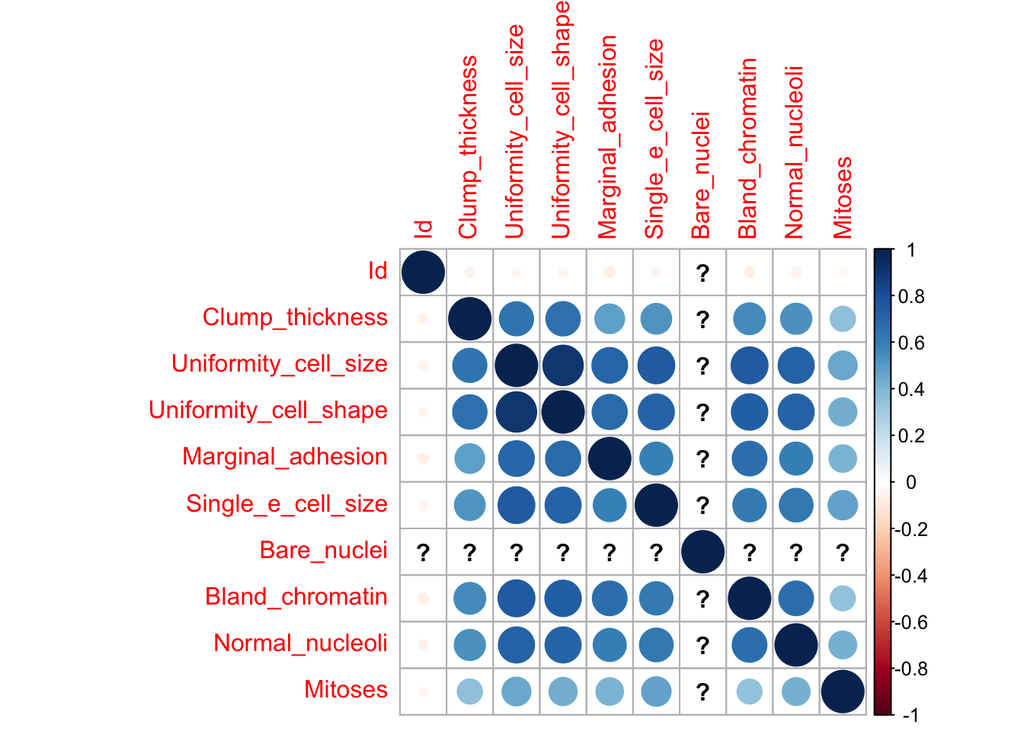

```r
corrplot::corrplot(cor(bcancerdata[,1:10]))

set.seed(100)
library(caret)
```

```r
library(pROC)
trainingRows <- createDataPartition(bcancerdata$Class, p = .80, list = FALSE)

# Subset the data into training and testing.
train <- bcancerdata[trainingRows, ]
test <- bcancerdata[-trainingRows, ]

trainimp <- preProcess(train, "knnImpute")
trainpr <- predict(trainimp, train)
testpr <- predict(trainimp, test)

summary(trainpr)
```

```
##        Id          Clump_thickness   Uniformity_cell_size Uniformity_cell_shape
##  Min.   :-1.5033   Min.   :-1.2309   Min.   :-0.6934      Min.   :-0.7465
##  1st Qu.:-0.2846   1st Qu.:-0.8730   1st Qu.:-0.6934      1st Qu.:-0.7465
##  Median : 0.1410   Median :-0.1572   Median :-0.6934      Median :-0.7465
##  Mean   : 0.0000   Mean   : 0.0000   Mean   : 0.0000      Mean   : 0.0000
##  3rd Qu.: 0.2343   3rd Qu.: 0.5586   3rd Qu.: 0.2880      3rd Qu.: 0.6119
##  Max.   :18.3077   Max.   : 1.9902   Max.   : 2.2509      Max.   : 2.3099
##  Marginal_adhesion Single_e_cell_size  Bare_nuclei        Bland_chromatin
##  Min.   :-0.6356   Min.   :-0.9995    Min.   :-0.701346   Min.   :-1.0025
##  1st Qu.:-0.6356   1st Qu.:-0.5466    1st Qu.:-0.701346   1st Qu.:-0.5989
##  Median :-0.6356   Median :-0.5466    Median :-0.701346   Median :-0.1953
##  Mean   : 0.0000   Mean   : 0.0000    Mean   :-0.002219   Mean   : 0.0000
##  3rd Qu.: 0.1725   3rd Qu.: 0.3590    3rd Qu.: 0.939294   3rd Qu.: 0.6119
##  Max.   : 2.5969   Max.   : 3.0761    Max.   : 1.759614   Max.   : 2.6298
##  Normal_nucleoli      Mitoses             Class
##  Min.   :-0.6153   Min.   :-0.326   benign   :367
##  1st Qu.:-0.6153   1st Qu.:-0.326   malignant:193
##  Median :-0.6153   Median :-0.326
##  Mean   : 0.0000   Mean   : 0.000
##  3rd Qu.: 0.3590   3rd Qu.:-0.326
##  Max.   : 2.3074   Max.   : 5.133
```

```r
summary(testpr)
```

```
##        Id           Clump_thickness    Uniformity_cell_size
##  Min.   :-1.18892   Min.   :-1.23093   Min.   :-0.69344
##  1st Qu.:-0.34650   1st Qu.:-1.05198   1st Qu.:-0.69344
##  Median : 0.13385   Median :-0.15722   Median :-0.69344
##  Mean   :-0.04591   Mean   :-0.03878   Mean   : 0.02441
##  3rd Qu.: 0.24071   3rd Qu.: 0.37963   3rd Qu.: 0.61516
##  Max.   : 0.43496   Max.   : 1.99020   Max.   : 2.25091
##  Uniformity_cell_shape Marginal_adhesion  Single_e_cell_size  Bare_nuclei
##  Min.   :-0.74652      Min.   :-0.63560   Min.   :-0.99948   Min.   :-0.70135
##  1st Qu.:-0.74652      1st Qu.:-0.63560   1st Qu.:-0.54664   1st Qu.:-0.70135
##  Median :-0.74652      Median :-0.63560   Median :-0.54664   Median :-0.70135
##  Mean   : 0.01575      Mean   : 0.06723   Mean   : 0.02022   Mean   :-0.04194
##  3rd Qu.: 0.27229      3rd Qu.: 0.44190   3rd Qu.: 0.35904   3rd Qu.: 0.39241
##  Max.   : 2.30990      Max.   : 2.59691   Max.   : 3.07608   Max.   : 1.75961
##  Bland_chromatin    Normal_nucleoli       Mitoses              Class
##  Min.   :-1.00249   Min.   :-0.61527   Min.   :-0.3260   benign   :91
##  1st Qu.:-0.59890   1st Qu.:-0.61527   1st Qu.:-0.3260   malignant:48
##  Median :-0.19531   Median :-0.61527   Median :-0.3260
##  Mean   :-0.09369   Mean   :-0.04522   Mean   : 0.1584
##  3rd Qu.: 0.20828   3rd Qu.: 0.03421   3rd Qu.:-0.3260
##  Max.   : 2.62983   Max.   : 2.30739   Max.   : 5.1333
```

### Mixture Discriminant Analysis

```r
ctrl <- trainControl(method = "cv",
                     summaryFunction = twoClassSummary,
                     classProbs = TRUE,
                     savePredictions = TRUE)

set.seed(476)

mdaFit <- train(x = trainpr[,1:10],
               y = trainpr$Class,
               method = "mda",
               tuneGrid = expand.grid(subclasses=1:3),
               metric = "ROC",
               trControl = ctrl)
mdaFit
```

```
## Mixture Discriminant Analysis
##
## 560 samples
##  10 predictor
##   2 classes: 'benign', 'malignant'
##
## No pre-processing
## Resampling: Cross-Validated (10 fold)
## Summary of sample sizes: 505, 505, 503, 504, 504, 504, ...
## Resampling results across tuning parameters:
##
##   subclasses  ROC        Sens       Spec
##   1           0.9932610  0.9756006  0.9265789
##   2           0.9932434  0.9756006  0.9371053
##   3           0.9898335  0.9728979  0.9265789
##
## ROC was used to select the optimal model using the largest value.
## The final value used for the model was subclasses = 1.
```

```r
mdaFit$finalModel
```

```
## Call:
## mda::mda(formula = as.formula(".outcome ~ ."), data = dat, subclasses = param$subclasses)
##
## Dimension: 1
##
## Percent Between-Group Variance Explained:
##  v1
## 100
##
## Degrees of Freedom (per dimension): 11
##
## Training Misclassification Error: 0.0375 ( N = 560 )
##
## Deviance: 203.034
```

```r
mdaCM <- confusionMatrix(mdaFit, norm = "none")
mdaCM
```

```
## Cross-Validated (10 fold) Confusion Matrix
##
## (entries are un-normalized aggregated counts)
##
##            Reference
## Prediction  benign malignant
##   benign       358        14
##   malignant      9       179
##
##  Accuracy (average) : 0.9589
```

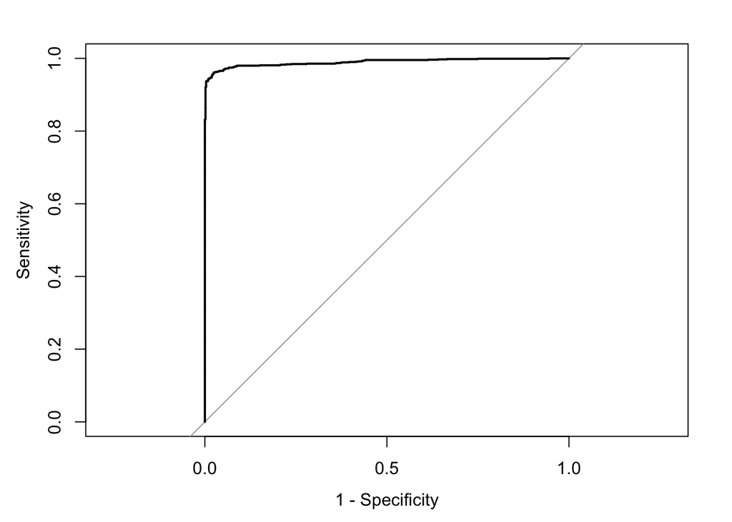

```r
## Plot the ROC curve for the hold-out set
mdaRoc <- roc(response = mdaFit$pred$obs,
             predictor = mdaFit$pred$malignant,
             levels = rev(levels(mdaFit$pred$obs)))
plot(mdaRoc, legacy.axes = TRUE)
```

```r
mdaRoc$auc
```

```
## Area under the curve: 0.9898
```

```r
mdaImp <- varImp(mdaFit, scale = FALSE)
plot(mdaImp)
```

[output not shown]

```r
testResults <- data.frame(obs = testpr$Class,
                          mda = predict(mdaFit, testpr[,1:10]))
```

### Single hidden layer neural network

Neural networks for classification use cross entropy as loss function instead of mean squared error loss function that was used for the regression. Backpropogation is the algorithm that is used to estimate the coefficients of a Neural network model. For a single hidden layer neural network, we have two tuning parameters, number of hidden units and decay parameters that controls regularization.

```r
set.seed(476)

nnetGrid <- expand.grid(size=1:3, decay=c(0,0.1,0.2,0.3,0.4,0.5,1,2))

nnetFit <- train(x = trainpr[,1:10],
                y = trainpr$Class,
                method = "nnet",
                tuneGrid = nnetGrid,
                metric = "ROC",
                trace = FALSE,
                maxit = 2000,
                trControl = ctrl)
nnetFit
```

```
## Neural Network
##
## 560 samples
##  10 predictor
##   2 classes: 'benign', 'malignant'
##
## No pre-processing
## Resampling: Cross-Validated (10 fold)
## Summary of sample sizes: 505, 505, 503, 504, 504, 504, ...
## Resampling results across tuning parameters:
##
##   size  decay  ROC        Sens       Spec
##   1     0.0    0.9668964  0.9455706  0.9686842
##   1     0.1    0.9922746  0.9510511  0.9526316
##   1     0.2    0.9921252  0.9566066  0.9526316
##   1     0.3    0.9908885  0.9620120  0.9526316
##   1     0.4    0.9936733  0.9674174  0.9476316
##   1     0.5    0.9938195  0.9646396  0.9476316
##   1     1.0    0.9938308  0.9646396  0.9528947
##   1     2.0    0.9932650  0.9646396  0.9528947
##   2     0.0    0.9668083  0.9509760  0.9428947
##   2     0.1    0.9915675  0.9538288  0.9526316
##   2     0.2    0.9927098  0.9701201  0.9473684
##   2     0.3    0.9929872  0.9673423  0.9526316
##   2     0.4    0.9935633  0.9701201  0.9476316
##   2     0.5    0.9927029  0.9701201  0.9476316
##   2     1.0    0.9932721  0.9674174  0.9476316
##   2     2.0    0.9934072  0.9646396  0.9528947
##   3     0.0    0.9711811  0.9591592  0.9421053
##   3     0.1    0.9898643  0.9592342  0.9526316
##   3     0.2    0.9926989  0.9620120  0.9423684
##   3     0.3    0.9922858  0.9701201  0.9476316
##   3     0.4    0.9929908  0.9674174  0.9476316
##   3     0.5    0.9930083  0.9674174  0.9476316
##   3     1.0    0.9935495  0.9674174  0.9476316
##   3     2.0    0.9934072  0.9674174  0.9528947
##
## ROC was used to select the optimal model using the largest value.
## The final values used for the model were size = 1 and decay = 1.
```

```r
nnetFit$finalModel
```

```
## a 10-1-1 network with 13 weights
## inputs: Id Clump_thickness Uniformity_cell_size Uniformity_cell_shape Marginal_adhesion Single_e_cell_size Bare_nuclei Bland_chromatin Normal_nucleoli Mitoses
## output(s): .outcome
## options were - entropy fitting  decay=1
```

```r
nnetCM <- confusionMatrix(nnetFit, norm = "none")
nnetCM
```

```
## Cross-Validated (10 fold) Confusion Matrix
##
## (entries are un-normalized aggregated counts)
##
##            Reference
## Prediction  benign malignant
##   benign       354         9
##   malignant     13       184
##
##  Accuracy (average) : 0.9607
```

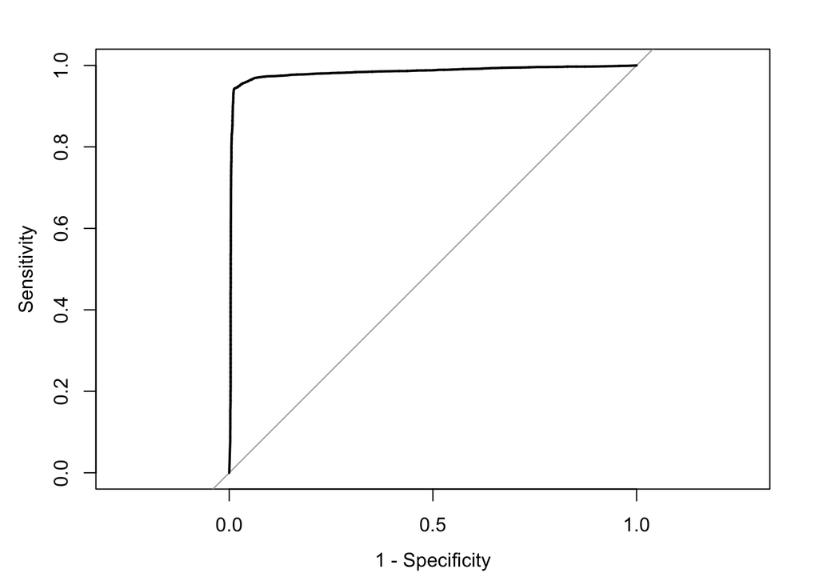

```r
## Plot the ROC curve for the hold-out set
nnetRoc <- roc(response = nnetFit$pred$obs,
              predictor = nnetFit$pred$malignant,
              levels = rev(levels(nnetFit$pred$obs)))
plot(nnetRoc, legacy.axes = TRUE)
```

```r
nnetRoc$auc
```

```
## Area under the curve: 0.9825
```

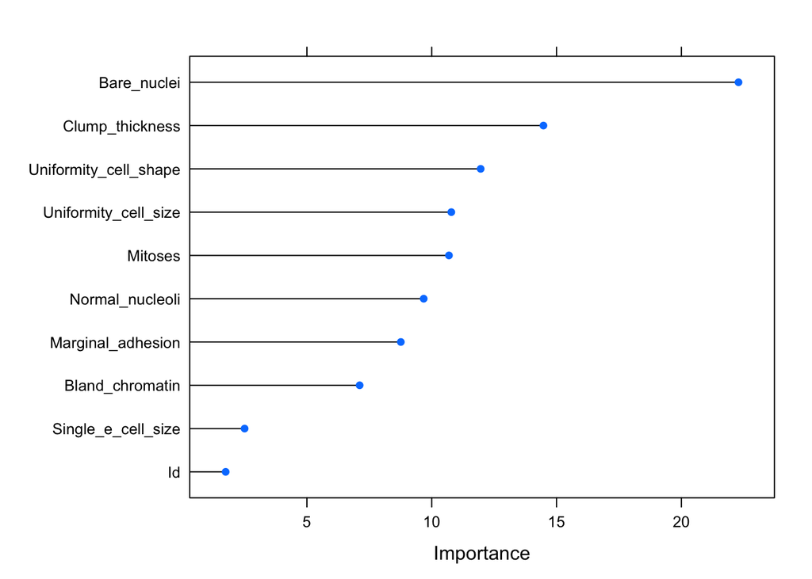

```r
nnetImp <- varImp(nnetFit, scale = FALSE)
plot(nnetImp)
```

```r
testResults$nnet <- predict(nnetFit, testpr[,1:10])
```

### Support Vector Machines

Cost is applied on errors not on the coefficients in the SVM. Errors are training set data points that are on or the wrong side of the decision boundary. To separate nonlinear data we use kernel functions that map data into higher dimensions where the data could be linearly seperated.

```r
sigmaEst <- kernlab::sigest(as.matrix(trainpr[,1:10]))
svmgrid <- expand.grid(sigma = sigmaEst, C = 2^seq(-4,+4))

set.seed(476)
svmRFit <- train(x = trainpr[,1:10],
                y = trainpr$Class,
                method = "svmRadial",
                tuneGrid = svmgrid,
                metric = "ROC",
                trControl = ctrl)
svmRFit
```

```
## Support Vector Machines with Radial Basis Function Kernel
##
## 560 samples
##  10 predictor
##   2 classes: 'benign', 'malignant'
##
## No pre-processing
## Resampling: Cross-Validated (10 fold)
## Summary of sample sizes: 505, 505, 503, 504, 504, 504, ...
## Resampling results across tuning parameters:
##
##   sigma       C        ROC        Sens       Spec
##   0.02208218   0.0625  0.9913616  0.9647147  0.9634211
##   0.02208218   0.1250  0.9919164  0.9647147  0.9634211
##   0.02208218   0.2500  0.9920444  0.9674174  0.9528947
##   0.02208218   0.5000  0.9913431  0.9701201  0.9476316
##   0.02208218   1.0000  0.9916240  0.9673423  0.9528947
##   0.02208218   2.0000  0.9914669  0.9673423  0.9423684
##   0.02208218   4.0000  0.9909299  0.9646396  0.9476316
##   0.02208218   8.0000  0.9918949  0.9619369  0.9476316
##   0.02208218  16.0000  0.9917340  0.9592342  0.9423684
##   0.07019114   0.0625  0.9882195  0.9566066  0.9634211
##   0.07019114   0.1250  0.9886249  0.9593093  0.9634211
##   0.07019114   0.2500  0.9883482  0.9593093  0.9581579
##   0.07019114   0.5000  0.9888919  0.9565315  0.9528947
##   0.07019114   1.0000  0.9897139  0.9565315  0.9528947
##   0.07019114   2.0000  0.9909118  0.9538288  0.9476316
##   0.07019114   4.0000  0.9910366  0.9565315  0.9476316
##   0.07019114   8.0000  0.9886206  0.9511261  0.9423684
##   0.07019114  16.0000  0.9863055  0.9456456  0.9268421
##   1.18512620   0.0625  0.9808825  0.8774775  1.0000000
##   1.18512620   0.1250  0.9804700  0.8966967  0.9894737
##   1.18512620   0.2500  0.9800433  0.9102102  0.9894737
##   1.18512620   0.5000  0.9792001  0.9183934  0.9894737
##   1.18512620   1.0000  0.9783387  0.9237988  0.9844737
##   1.18512620   2.0000  0.9787188  0.9265766  0.9844737
##   1.18512620   4.0000  0.9787188  0.9292793  0.9844737
##   1.18512620   8.0000  0.9787188  0.9265766  0.9844737
##   1.18512620  16.0000  0.9787188  0.9265766  0.9844737
##
## ROC was used to select the optimal model using the largest value.
## The final values used for the model were sigma = 0.02208218 and C = 0.25.
```

```r
svmRFit$finalModel
```

```
## Support Vector Machine object of class "ksvm"
##
## SV type: C-svc  (classification)
##  parameter : cost C = 0.25
##
## Gaussian Radial Basis kernel function.
##  Hyperparameter : sigma =  0.0220821793584673
##
## Number of Support Vectors : 108
##
## Objective Function Value : -19.9859
## Training error : 0.033929
## Probability model included.
```

```r
svmRCM <- confusionMatrix(svmRFit, norm = "none")
svmRCM
```

```
## Cross-Validated (10 fold) Confusion Matrix
##
## (entries are un-normalized aggregated counts)
##
##            Reference
## Prediction  benign malignant
##   benign       355         9
##   malignant     12       184
##
##  Accuracy (average) : 0.9625
```

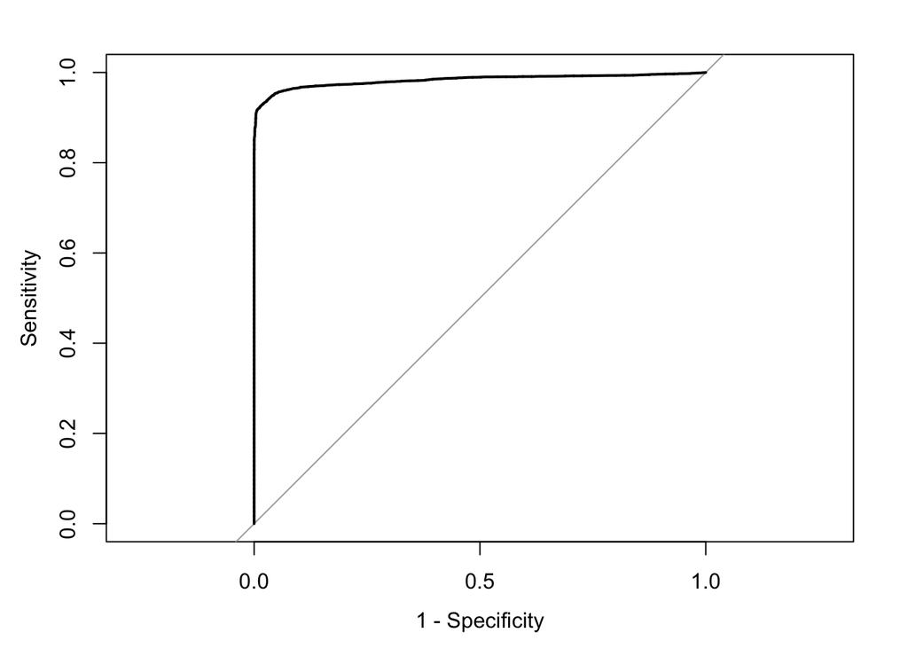

```r
## Plot the ROC curve for the hold-out set
svmRRoc <- roc(response = svmRFit$pred$obs,
              predictor = svmRFit$pred$malignant,
              levels = rev(levels(svmRFit$pred$obs)))
plot(svmRRoc, legacy.axes = TRUE)
```

```r
svmRRoc$auc
```

```
## Area under the curve: 0.9829
```

```r
svmRImp <- varImp(svmRFit, scale = FALSE)
plot(svmRImp)
```

[output not shown]

```r
testResults$svmR <- predict(svmRFit, testpr[,1:10])
```

### K-Nearest Neighbors

Classification is done by majority voting from the k nearest neighbors. Ties are broken by checking the k+1 th training data point.

```r
set.seed(476)
knnFit <- train(x = trainpr[,1:10],
                y = trainpr$Class,
                method = "knn",
                tuneLength = 20,
                metric = "ROC",
                trControl = ctrl)
knnFit
```

```
## k-Nearest Neighbors
##
## 560 samples
##  10 predictor
##   2 classes: 'benign', 'malignant'
##
## No pre-processing
## Resampling: Cross-Validated (10 fold)
## Summary of sample sizes: 505, 505, 503, 504, 504, 504, ...
## Resampling results across tuning parameters:
##
##   k   ROC        Sens       Spec
##    5  0.9779926  0.9674174  0.9476316
##    7  0.9802090  0.9674174  0.9476316
##    9  0.9828501  0.9646396  0.9476316
##   11  0.9851367  0.9701201  0.9528947
##   13  0.9870288  0.9701201  0.9528947
##   15  0.9883905  0.9674174  0.9634211
##   17  0.9903536  0.9674174  0.9581579
##   19  0.9898643  0.9701201  0.9634211
##   21  0.9896545  0.9701201  0.9634211
##   23  0.9892348  0.9701201  0.9531579
##   25  0.9892402  0.9701201  0.9423684
##   27  0.9891015  0.9701201  0.9373684
##   29  0.9884756  0.9701201  0.9423684
##   31  0.9882693  0.9701201  0.9321053
##   33  0.9878510  0.9701201  0.9423684
##   35  0.9872251  0.9701201  0.9423684
##   37  0.9875096  0.9701201  0.9423684
##   39  0.9876535  0.9701201  0.9371053
##   41  0.9873138  0.9701201  0.9373684
##   43  0.9868864  0.9701201  0.9373684
##
## ROC was used to select the optimal model using the largest value.
## The final value used for the model was k = 17.
```

```r
knnFit$finalModel
```

```
## 17-nearest neighbor model
## Training set outcome distribution:
##
##    benign malignant
##       367       193
```

```r
knnCM <- confusionMatrix(knnFit, norm = "none")
knnCM
```

```
## Cross-Validated (10 fold) Confusion Matrix
##
## (entries are un-normalized aggregated counts)
##
##            Reference
## Prediction  benign malignant
##   benign       355         8
##   malignant     12       185
##
##  Accuracy (average) : 0.9643
```

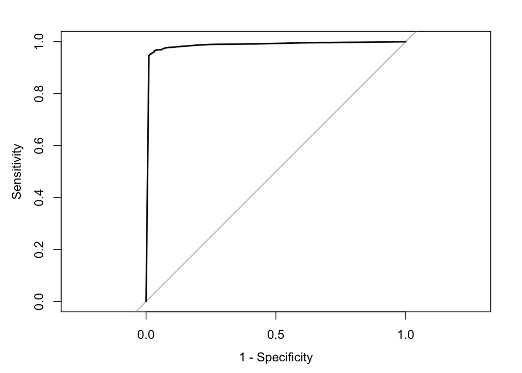

```r
## Plot the ROC curve for the hold-out set
knnRoc <- roc(response = knnFit$pred$obs,
              predictor = knnFit$pred$malignant,
              levels = rev(levels(knnFit$pred$obs)))
plot(knnRoc, legacy.axes = TRUE)
```

```r
knnRoc$auc
```

```
## Area under the curve: 0.9856
```

```r
knnImp <- varImp(knnFit, scale = FALSE)
plot(knnImp)
```

[output not shown]

```r
testResults$knn <- predict(knnFit, testpr[,1:10])
```

### Model performance comparison between non-linear classifiers

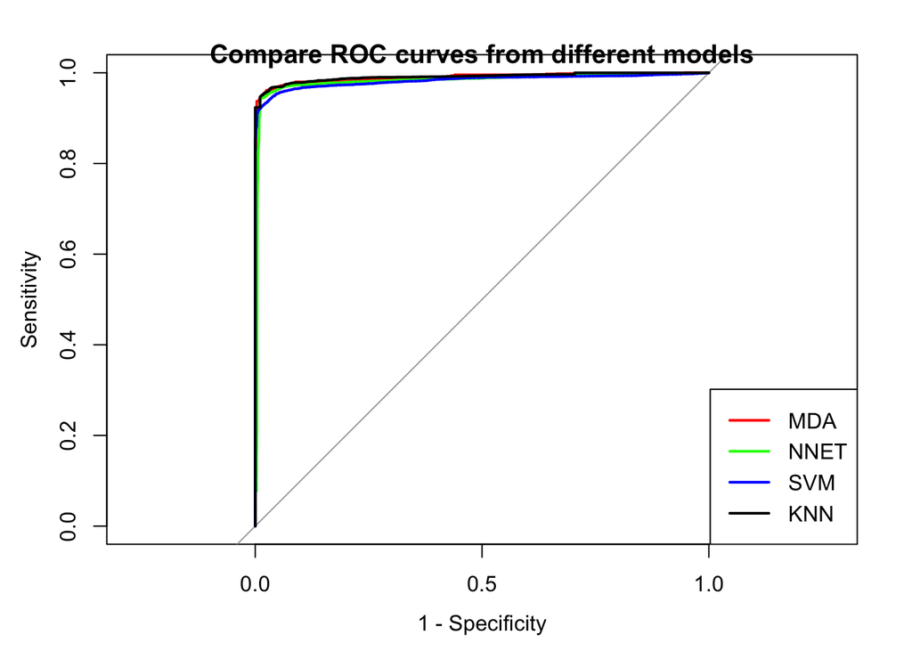

```r
### Compare Models using ROC curve

plot(mdaRoc, type = "s", col = 'red', legacy.axes = TRUE)
plot(nnetRoc, type = "s", add = TRUE, col = 'green', legacy.axes = TRUE)
plot(svmRRoc, type = "s", add = TRUE, col = 'blue', legacy.axes = TRUE)
plot(knnRoc, type = "s", add = TRUE, legacy.axes = TRUE)
legend("bottomright", legend=c("MDA", "NNET", "SVM", "KNN"),
       col=c("red", "green","blue", "black"), lwd=2)
title(main = "Compare ROC curves from different models")
```

```r
### Compare Models using confusion matrix

confusionMatrix(testResults$mda, testResults$obs, positive = "malignant")
```

```
## Confusion Matrix and Statistics
##
##            Reference
## Prediction  benign malignant
##   benign        90         7
##   malignant      1        41
##
##                Accuracy : 0.9424
##                  95% CI : (0.8897, 0.9748)
##     No Information Rate : 0.6547
##     P-Value [Acc > NIR] : 5.092e-16
##
##                   Kappa : 0.8688
##
##  Mcnemar's Test P-Value : 0.0771
##
##             Sensitivity : 0.8542
##             Specificity : 0.9890
##          Pos Pred Value : 0.9762
##          Neg Pred Value : 0.9278
##              Prevalence : 0.3453
##          Detection Rate : 0.2950
##    Detection Prevalence : 0.3022
##       Balanced Accuracy : 0.9216
##
##        'Positive' Class : malignant
##
```

```r
confusionMatrix(testResults$nnet, testResults$obs, positive = "malignant")
```

```
## Confusion Matrix and Statistics
##
##            Reference
## Prediction  benign malignant
##   benign        90         1
##   malignant      1        47
##
##                Accuracy : 0.9856
##                  95% CI : (0.949, 0.9983)
##     No Information Rate : 0.6547
##     P-Value [Acc > NIR] : <2e-16
##
##                   Kappa : 0.9682
##
##  Mcnemar's Test P-Value : 1
##
##             Sensitivity : 0.9792
##             Specificity : 0.9890
##          Pos Pred Value : 0.9792
##          Neg Pred Value : 0.9890
##              Prevalence : 0.3453
##          Detection Rate : 0.3381
##    Detection Prevalence : 0.3453
##       Balanced Accuracy : 0.9841
##
##        'Positive' Class : malignant
##
```

```r
confusionMatrix(testResults$svmR, testResults$obs, positive = "malignant")
```

```
## Confusion Matrix and Statistics
##
##            Reference
## Prediction  benign malignant
##   benign        90         2
##   malignant      1        46
##
##                Accuracy : 0.9784
##                  95% CI : (0.9382, 0.9955)
##     No Information Rate : 0.6547
##     P-Value [Acc > NIR] : <2e-16
##
##                   Kappa : 0.952
##
##  Mcnemar's Test P-Value : 1
##
##             Sensitivity : 0.9583
##             Specificity : 0.9890
##          Pos Pred Value : 0.9787
##          Neg Pred Value : 0.9783
##              Prevalence : 0.3453
##          Detection Rate : 0.3309
##    Detection Prevalence : 0.3381
##       Balanced Accuracy : 0.9737
##
##        'Positive' Class : malignant
##
```

```r
confusionMatrix(testResults$knn, testResults$obs, positive = "malignant")
```

```
## Confusion Matrix and Statistics
##
##            Reference
## Prediction  benign malignant
##   benign        90         3
##   malignant      1        45
##
##                Accuracy : 0.9712
##                  95% CI : (0.928, 0.9921)
##     No Information Rate : 0.6547
##     P-Value [Acc > NIR] : <2e-16
##
##                   Kappa : 0.9357
##
##  Mcnemar's Test P-Value : 0.6171
##
##             Sensitivity : 0.9375
##             Specificity : 0.9890
##          Pos Pred Value : 0.9783
##          Neg Pred Value : 0.9677
##              Prevalence : 0.3453
##          Detection Rate : 0.3237
##    Detection Prevalence : 0.3309
##       Balanced Accuracy : 0.9633
##
##        'Positive' Class : malignant
##
```

### Decision Trees

```r
set.seed(476)
rpartFit <- train(x = trainpr[,1:10],
                y = trainpr$Class,
                method = "rpart",
                tuneLength = 30,
                metric = "ROC",
                trControl = ctrl)
rpartFit
```

```
## CART
##
## 560 samples
##  10 predictor
##   2 classes: 'benign', 'malignant'
##
## No pre-processing
## Resampling: Cross-Validated (10 fold)
## Summary of sample sizes: 505, 505, 503, 504, 504, 504, ...
## Resampling results across tuning parameters:
##
##   cp          ROC        Sens       Spec
##   0.00000000  0.9579050  0.9566066  0.8965789
##   0.02680007  0.9390582  0.9346096  0.9278947
##   0.05360014  0.9260374  0.9155405  0.9278947
##   0.08040021  0.9191801  0.9154655  0.9228947
##   0.10720029  0.9191801  0.9154655  0.9228947
##   0.13400036  0.9191801  0.9154655  0.9228947
##   0.16080043  0.9191801  0.9154655  0.9228947
##   0.18760050  0.9191801  0.9154655  0.9228947
##   0.21440057  0.9191801  0.9154655  0.9228947
##   0.24120064  0.9191801  0.9154655  0.9228947
##   0.26800071  0.9191801  0.9154655  0.9228947
##   0.29480079  0.9191801  0.9154655  0.9228947
##   0.32160086  0.9191801  0.9154655  0.9228947
##   0.34840093  0.9191801  0.9154655  0.9228947
##   0.37520100  0.9191801  0.9154655  0.9228947
##   0.40200107  0.9191801  0.9154655  0.9228947
##   0.42880114  0.9191801  0.9154655  0.9228947
##   0.45560121  0.9191801  0.9154655  0.9228947
##   0.48240129  0.9191801  0.9154655  0.9228947
##   0.50920136  0.9191801  0.9154655  0.9228947
##   0.53600143  0.9191801  0.9154655  0.9228947
##   0.56280150  0.9191801  0.9154655  0.9228947
##   0.58960157  0.9191801  0.9154655  0.9228947
##   0.61640164  0.9191801  0.9154655  0.9228947
##   0.64320172  0.9191801  0.9154655  0.9228947
##   0.67000179  0.9191801  0.9154655  0.9228947
##   0.69680186  0.9191801  0.9154655  0.9228947
##   0.72360193  0.9191801  0.9154655  0.9228947
##   0.75040200  0.9191801  0.9154655  0.9228947
##   0.77720207  0.6550933  0.9509760  0.3592105
##
## ROC was used to select the optimal model using the largest value.
## The final value used for the model was cp = 0.
```

```r
rpartFit$finalModel
```

```
## n= 560
##
## node), split, n, loss, yval, (yprob)
##       * denotes terminal node
##
##   1) root 560 193 benign (0.655357143 0.344642857)
##     2) Uniformity_cell_size< -0.202716 344  10 benign (0.970930233 0.029069767)
##       4) Normal_nucleoli< 0.1965837 335   3 benign (0.991044776 0.008955224) *
##       5) Normal_nucleoli>=0.1965837 9   2 malignant (0.222222222 0.777777778) *
##     3) Uniformity_cell_size>=-0.202716 216  33 malignant (0.152777778 0.847222222)
##       6) Uniformity_cell_shape< -0.2371146 18   4 benign (0.777777778 0.222222222) *
##       7) Uniformity_cell_shape>=-0.2371146 198  19 malignant (0.095959596 0.904040404)
##        14) Bare_nuclei< 1.404142 92  18 malignant (0.195652174 0.804347826)
##          28) Clump_thickness< 0.7375382 44  16 malignant (0.363636364 0.636363636)
##            56) Normal_nucleoli< 1.820284 28  13 benign (0.535714286 0.464285714)
##             112) Marginal_adhesion< 0.2623207 15   3 benign (0.800000000 0.200000000) *
##             113) Marginal_adhesion>=0.2623207 13   3 malignant (0.230769231 0.769230769) *
##            57) Normal_nucleoli>=1.820284 16   1 malignant (0.062500000 0.937500000) *
##          29) Clump_thickness>=0.7375382 48   2 malignant (0.041666667 0.958333333) *
##        15) Bare_nuclei>=1.404142 106   1 malignant (0.009433962 0.990566038) *
```

```r
rpartCM <- confusionMatrix(rpartFit, norm = "none")
rpartCM
```

```
## Cross-Validated (10 fold) Confusion Matrix
##
## (entries are un-normalized aggregated counts)
##
##            Reference
## Prediction  benign malignant
##   benign       351        20
##   malignant     16       173
##
##  Accuracy (average) : 0.9357
```

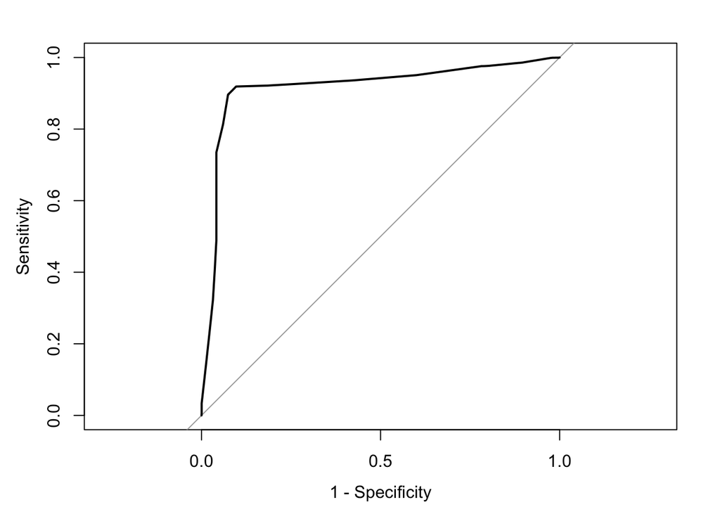

```r
## Plot the ROC curve for the hold-out set
rpartRoc <- roc(response = rpartFit$pred$obs,
              predictor = rpartFit$pred$malignant,
              levels = rev(levels(rpartFit$pred$obs)))
plot(rpartRoc, legacy.axes = TRUE)
```

```r
rpartRoc$auc
```

```
## Area under the curve: 0.916
```

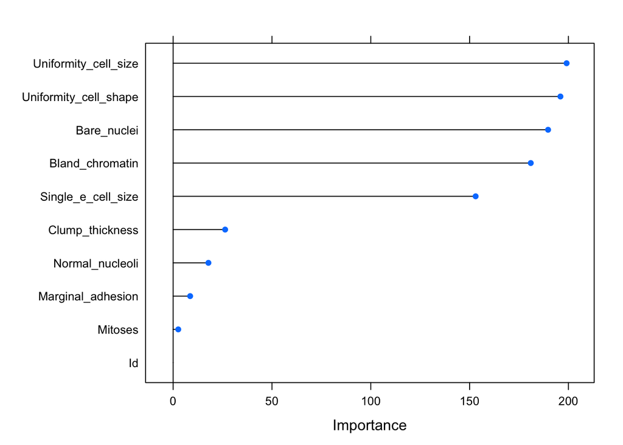

```r
rpartImp <- varImp(rpartFit, scale = FALSE)
plot(rpartImp)
```

```r
testResults$rpart <- predict(rpartFit, testpr[,1:10])
```

### Bagged Trees

```r
set.seed(476)

treebagFit <- train(x = trainpr[,1:10],
                y = trainpr$Class,
                method = "treebag",
                nbagg = 50,
                metric = "ROC",
                trControl = ctrl)
treebagFit
```

```
## Bagged CART
##
## 560 samples
##  10 predictor
##   2 classes: 'benign', 'malignant'
##
## No pre-processing
## Resampling: Cross-Validated (10 fold)
## Summary of sample sizes: 505, 505, 503, 504, 504, 504, ...
## Resampling results:
##
##   ROC        Sens      Spec
##   0.9891992  0.962012  0.9686842
```

```r
treebagFit$finalModel
```

```
##
## Bagging classification trees with 50 bootstrap replications
```

```r
treebagCM <- confusionMatrix(treebagFit, norm = "none")
treebagCM
```

```
## Cross-Validated (10 fold) Confusion Matrix
##
## (entries are un-normalized aggregated counts)
##
##            Reference
## Prediction  benign malignant
##   benign       353         6
##   malignant     14       187
##
##  Accuracy (average) : 0.9643
```

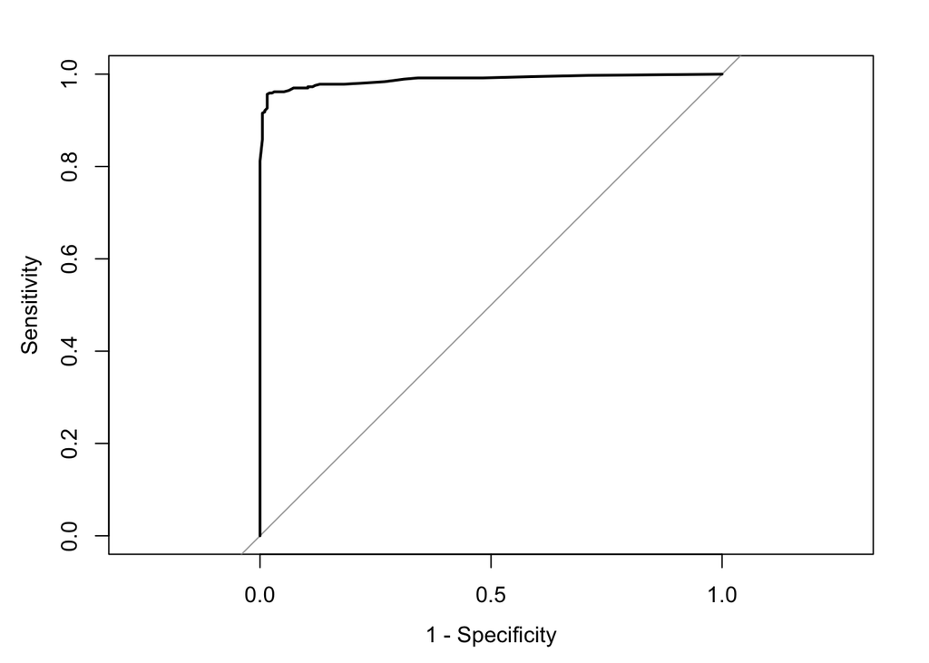

```r
## Plot the ROC curve for the hold-out set
treebagRoc <- roc(response = treebagFit$pred$obs,
              predictor = treebagFit$pred$malignant,
              levels = rev(levels(treebagFit$pred$obs)))
plot(treebagRoc, legacy.axes = TRUE)
```

```r
treebagRoc$auc
```

```
## Area under the curve: 0.9882
```

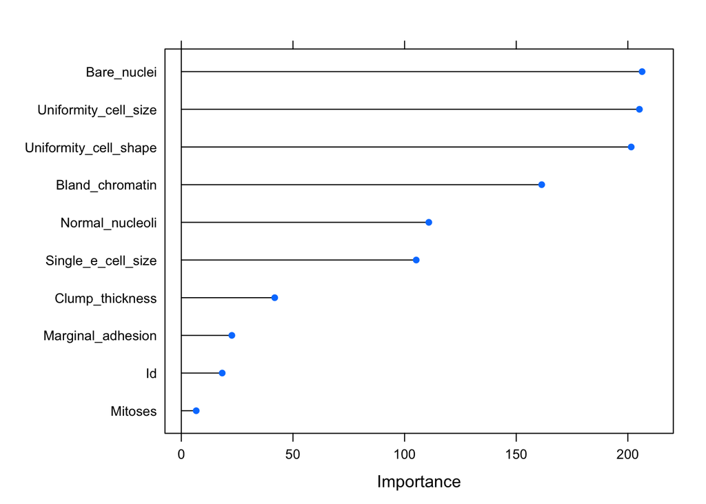

```r
treebagImp <- varImp(treebagFit, scale = FALSE)
plot(treebagImp)
```

```r
testResults$treebag <- predict(treebagFit, testpr[,1:10])
```

### Random Forest Trees

```r
mtryValues <- seq(1,10,1)

set.seed(476)

rfFit <- train(x = trainpr[,1:10],
                y = trainpr$Class,
                method = "rf",
                ntree = 1000,
                tuneGrid = data.frame(mtry = mtryValues),
                metric = "ROC",
                trControl = ctrl)
rfFit
```

```
## Random Forest
##
## 560 samples
##  10 predictor
##   2 classes: 'benign', 'malignant'
##
## No pre-processing
## Resampling: Cross-Validated (10 fold)
## Summary of sample sizes: 505, 505, 503, 504, 504, 504, ...
## Resampling results across tuning parameters:
##
##   mtry  ROC        Sens       Spec
##    1    0.9912095  0.9645646  0.9842105
##    2    0.9915754  0.9645646  0.9842105
##    3    0.9911702  0.9673423  0.9842105
##    4    0.9910426  0.9646396  0.9842105
##    5    0.9910210  0.9619369  0.9739474
##    6    0.9908677  0.9619369  0.9736842
##    7    0.9911562  0.9619369  0.9686842
##    8    0.9906560  0.9619369  0.9739474
##    9    0.9908748  0.9619369  0.9739474
##   10    0.9901027  0.9619369  0.9739474
##
## ROC was used to select the optimal model using the largest value.
## The final value used for the model was mtry = 2.
```

```r
rfFit$finalModel
```

```
##
## Call:
##  randomForest(x = x, y = y, ntree = 1000, mtry = param$mtry)
##                Type of random forest: classification
##                      Number of trees: 1000
## No. of variables tried at each split: 2
##
##         OOB estimate of  error rate: 2.86%
## Confusion matrix:
##           benign malignant class.error
## benign       355        12  0.03269755
## malignant      4       189  0.02072539
```

```r
rfCM <- confusionMatrix(rfFit, norm = "none")
rfCM
```

```
## Cross-Validated (10 fold) Confusion Matrix
##
## (entries are un-normalized aggregated counts)
##
##            Reference
## Prediction  benign malignant
##   benign       354         3
##   malignant     13       190
##
##  Accuracy (average) : 0.9714
```

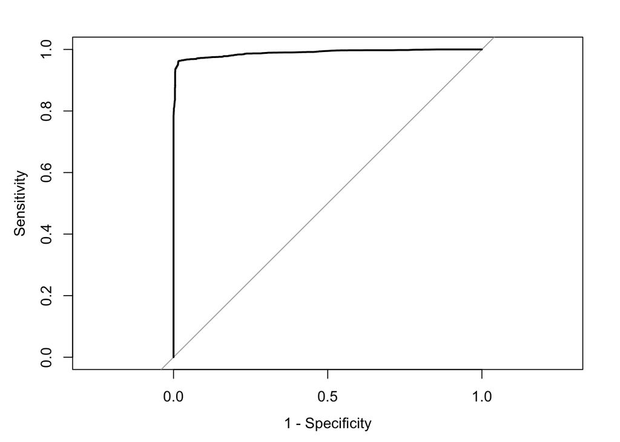

```r
## Plot the ROC curve for the hold-out set
rfRoc <- roc(response = rfFit$pred$obs,
              predictor = rfFit$pred$malignant,
              levels = rev(levels(rfFit$pred$obs)))
plot(rfRoc, legacy.axes = TRUE)
```

```r
rfRoc$auc
```

```
## Area under the curve: 0.9896
```

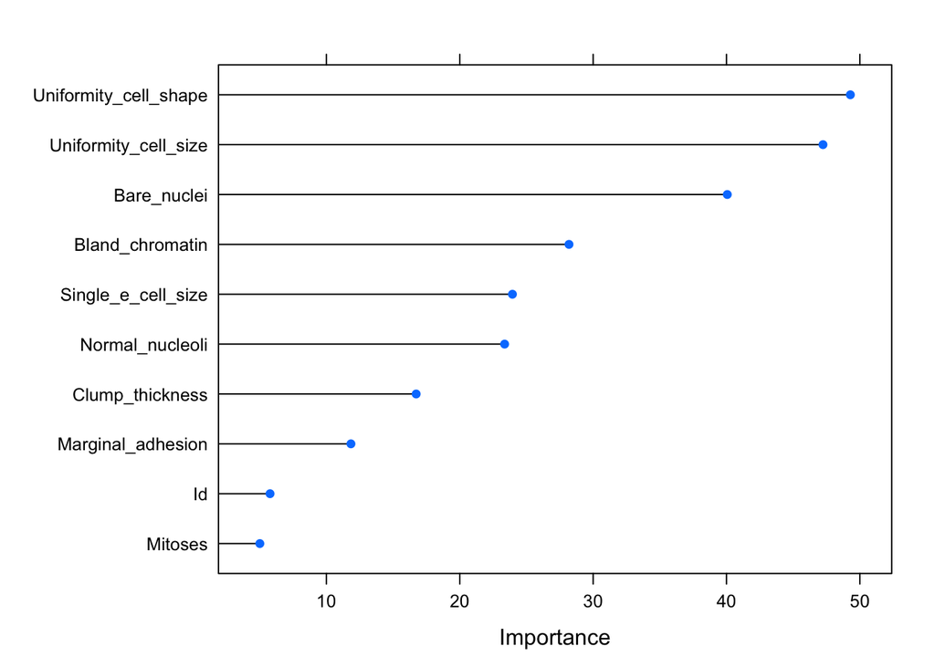

```r
rfImp <- varImp(rfFit, scale = FALSE)
plot(rfImp)
```

```r
testResults$rf <- predict(rfFit, testpr[,1:10])
```

### Boosted Trees

```r
gbmGrid <- expand.grid(interaction.depth = c(1, 3, 5, 7, 9),
                       n.trees = (1:20)*100,
                       shrinkage = c(.01, .1),
                       n.minobsinnode = 5)


set.seed(476)

gbmFit <- train(x = trainpr[,1:10],
                y = trainpr$Class,
                method = "gbm",
                tuneGrid = gbmGrid,
                verbose = FALSE,
                metric = "ROC",
                trControl = ctrl)
gbmFit
```

```
## Stochastic Gradient Boosting
##
## 560 samples
##  10 predictor
##   2 classes: 'benign', 'malignant'
##
## No pre-processing
## Resampling: Cross-Validated (10 fold)
## Summary of sample sizes: 505, 505, 503, 504, 504, 504, ...
## Resampling results across tuning parameters:
##
##   shrinkage  interaction.depth  n.trees  ROC        Sens       Spec
##   0.01       1                   100     0.9809037  0.9673423  0.8965789
##   0.01       1                   200     0.9853532  0.9645646  0.9226316
##   0.01       1                   300     0.9870288  0.9673423  0.9378947
##   0.01       1                   400     0.9881672  0.9673423  0.9426316
##   0.01       1                   500     0.9891345  0.9701201  0.9528947
##   0.01       1                   600     0.9894229  0.9701201  0.9476316
##   0.01       1                   700     0.9889924  0.9701201  0.9476316
##   0.01       1                   800     0.9889958  0.9701201  0.9423684
##   0.01       1                   900     0.9891380  0.9701201  0.9423684
##   0.01       1                  1000     0.9887042  0.9701201  0.9423684
##   0.01       1                  1100     0.9885619  0.9701201  0.9476316
##   0.01       1                  1200     0.9879929  0.9673423  0.9426316
##   0.01       1                  1300     0.9879929  0.9673423  0.9426316
##   0.01       1                  1400     0.9872991  0.9673423  0.9426316
##   0.01       1                  1500     0.9868794  0.9673423  0.9426316
##   0.01       1                  1600     0.9864565  0.9673423  0.9426316
##   0.01       1                  1700     0.9860218  0.9673423  0.9426316
##   0.01       1                  1800     0.9861569  0.9673423  0.9426316
##   0.01       1                  1900     0.9857302  0.9673423  0.9426316
##   0.01       1                  2000     0.9853072  0.9673423  0.9376316
##   0.01       3                   100     0.9862891  0.9673423  0.9123684
##   0.01       3                   200     0.9899117  0.9673423  0.9528947
##   0.01       3                   300     0.9904736  0.9674174  0.9526316
##   0.01       3                   400     0.9917427  0.9674174  0.9526316
##   0.01       3                   500     0.9916005  0.9674174  0.9528947
##   0.01       3                   600     0.9911809  0.9674174  0.9528947
##   0.01       3                   700     0.9911733  0.9701201  0.9528947
##   0.01       3                   800     0.9914507  0.9701201  0.9528947
```

[output cut: 162 more lines]

```
##   0.10       9                  1100     0.9904086  0.9646396  0.9684211
##   0.10       9                  1200     0.9887016  0.9646396  0.9684211
##   0.10       9                  1300     0.9894026  0.9646396  0.9684211
##   0.10       9                  1400     0.9893348  0.9646396  0.9684211
##   0.10       9                  1500     0.9891886  0.9646396  0.9684211
##   0.10       9                  1600     0.9869863  0.9618619  0.9684211
##   0.10       9                  1700     0.9891852  0.9618619  0.9684211
##   0.10       9                  1800     0.9887585  0.9618619  0.9684211
##   0.10       9                  1900     0.9887624  0.9618619  0.9684211
##   0.10       9                  2000     0.9887696  0.9618619  0.9684211
##
## Tuning parameter 'n.minobsinnode' was held constant at a value of 5
## ROC was used to select the optimal model using the largest value.
## The final values used for the model were n.trees = 100, interaction.depth =
##  3, shrinkage = 0.1 and n.minobsinnode = 5.
```

```r
gbmFit$finalModel
```

```
## A gradient boosted model with bernoulli loss function.
## 100 iterations were performed.
## There were 10 predictors of which 10 had non-zero influence.
```

```r
gbmCM <- confusionMatrix(gbmFit, norm = "none")
gbmCM
```

```
## Cross-Validated (10 fold) Confusion Matrix
##
## (entries are un-normalized aggregated counts)
##
##            Reference
## Prediction  benign malignant
##   benign       354         8
##   malignant     13       185
##
##  Accuracy (average) : 0.9625
```

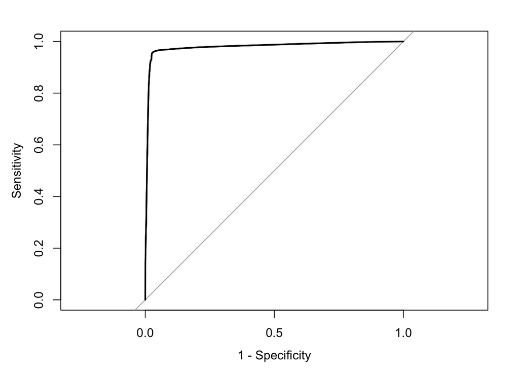

```r
## Plot the ROC curve for the hold-out set
gbmRoc <- roc(response = gbmFit$pred$obs,
              predictor = gbmFit$pred$malignant,
              levels = rev(levels(gbmFit$pred$obs)))
plot(gbmRoc, legacy.axes = TRUE)
```

```r
gbmRoc$auc
```

```
## Area under the curve: 0.9791
```

```r
library(gbm)
```

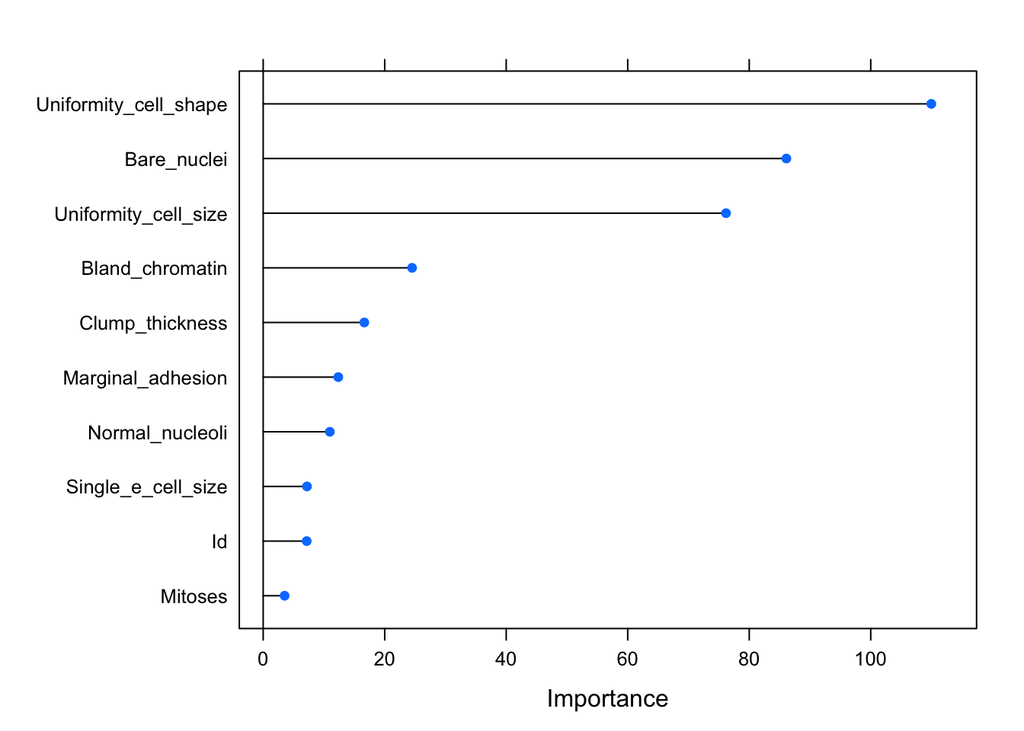

```r
gbmImp <- varImp(gbmFit, scale = FALSE)
plot(gbmImp)
```

```r
testResults$gbm <- predict(gbmFit, testpr[,1:10])
```

### Model Performance Comparison between tree based classifiers

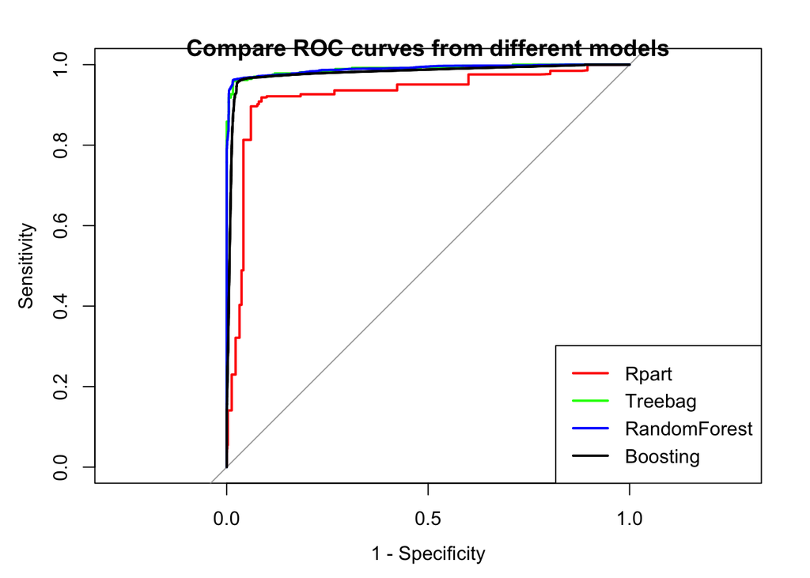

```r
### Compare Models using ROC curve

plot(rpartRoc, type = "s", col = 'red', legacy.axes = TRUE)
plot(treebagRoc, type = "s", add = TRUE, col = 'green', legacy.axes = TRUE)
plot(rfRoc, type = "s", add = TRUE, col = 'blue', legacy.axes = TRUE)
plot(gbmRoc, type = "s", add = TRUE, legacy.axes = TRUE)
legend("bottomright", legend = c("Rpart", "Treebag", "RandomForest", "Boosting"),
       col = c("red", "green","blue", "black"), lwd = 2)
title(main = "Compare ROC curves from different models")
```

```r
### Compare Models using confusion matrix

confusionMatrix(testResults$rpart, testResults$obs, positive = "malignant")
```

```
## Confusion Matrix and Statistics
##
##            Reference
## Prediction  benign malignant
##   benign        89         4
##   malignant      2        44
##
##                Accuracy : 0.9568
##                  95% CI : (0.9084, 0.984)
##     No Information Rate : 0.6547
##     P-Value [Acc > NIR] : <2e-16
##
##                   Kappa : 0.9036
##
##  Mcnemar's Test P-Value : 0.6831
##
##             Sensitivity : 0.9167
##             Specificity : 0.9780
##          Pos Pred Value : 0.9565
##          Neg Pred Value : 0.9570
##              Prevalence : 0.3453
##          Detection Rate : 0.3165
##    Detection Prevalence : 0.3309
##       Balanced Accuracy : 0.9473
##
##        'Positive' Class : malignant
##
```

```r
confusionMatrix(testResults$treebag, testResults$obs, positive = "malignant")
```

```
## Confusion Matrix and Statistics
##
##            Reference
## Prediction  benign malignant
##   benign        90         2
##   malignant      1        46
##
##                Accuracy : 0.9784
##                  95% CI : (0.9382, 0.9955)
##     No Information Rate : 0.6547
##     P-Value [Acc > NIR] : <2e-16
##
##                   Kappa : 0.952
##
##  Mcnemar's Test P-Value : 1
##
##             Sensitivity : 0.9583
##             Specificity : 0.9890
##          Pos Pred Value : 0.9787
##          Neg Pred Value : 0.9783
##              Prevalence : 0.3453
##          Detection Rate : 0.3309
##    Detection Prevalence : 0.3381
##       Balanced Accuracy : 0.9737
##
##        'Positive' Class : malignant
##
```

```r
confusionMatrix(testResults$rf, testResults$obs, positive = "malignant")
```

```
## Confusion Matrix and Statistics
##
##            Reference
## Prediction  benign malignant
##   benign        90         2
##   malignant      1        46
##
##                Accuracy : 0.9784
##                  95% CI : (0.9382, 0.9955)
##     No Information Rate : 0.6547
##     P-Value [Acc > NIR] : <2e-16
##
##                   Kappa : 0.952
##
##  Mcnemar's Test P-Value : 1
##
##             Sensitivity : 0.9583
##             Specificity : 0.9890
##          Pos Pred Value : 0.9787
##          Neg Pred Value : 0.9783
##              Prevalence : 0.3453
##          Detection Rate : 0.3309
##    Detection Prevalence : 0.3381
##       Balanced Accuracy : 0.9737
##
##        'Positive' Class : malignant
##
```

```r
confusionMatrix(testResults$gbm, testResults$obs, positive = "malignant")
```

```
## Confusion Matrix and Statistics
##
##            Reference
## Prediction  benign malignant
##   benign        89         0
##   malignant      2        48
##
##                Accuracy : 0.9856
##                  95% CI : (0.949, 0.9983)
##     No Information Rate : 0.6547
##     P-Value [Acc > NIR] : <2e-16
##
##                   Kappa : 0.9685
##
##  Mcnemar's Test P-Value : 0.4795
##
##             Sensitivity : 1.0000
##             Specificity : 0.9780
##          Pos Pred Value : 0.9600
##          Neg Pred Value : 1.0000
##              Prevalence : 0.3453
##          Detection Rate : 0.3453
##    Detection Prevalence : 0.3597
##       Balanced Accuracy : 0.9890
##
##        'Positive' Class : malignant
##
```

```r
### Compare best models
confusionMatrix(testResults$nnet, testResults$obs, positive = "malignant")
```

```
## Confusion Matrix and Statistics
##
##            Reference
## Prediction  benign malignant
##   benign        90         1
##   malignant      1        47
##
##                Accuracy : 0.9856
##                  95% CI : (0.949, 0.9983)
##     No Information Rate : 0.6547
##     P-Value [Acc > NIR] : <2e-16
##
##                   Kappa : 0.9682
##
##  Mcnemar's Test P-Value : 1
##
##             Sensitivity : 0.9792
##             Specificity : 0.9890
##          Pos Pred Value : 0.9792
##          Neg Pred Value : 0.9890
##              Prevalence : 0.3453
##          Detection Rate : 0.3381
##    Detection Prevalence : 0.3453
##       Balanced Accuracy : 0.9841
##
##        'Positive' Class : malignant
##
```

```r
confusionMatrix(testResults$gbm, testResults$obs, positive = "malignant")
```

```
## Confusion Matrix and Statistics
##
##            Reference
## Prediction  benign malignant
##   benign        89         0
##   malignant      2        48
##
##                Accuracy : 0.9856
##                  95% CI : (0.949, 0.9983)
##     No Information Rate : 0.6547
##     P-Value [Acc > NIR] : <2e-16
##
##                   Kappa : 0.9685
##
##  Mcnemar's Test P-Value : 0.4795
##
##             Sensitivity : 1.0000
##             Specificity : 0.9780
##          Pos Pred Value : 0.9600
##          Neg Pred Value : 1.0000
##              Prevalence : 0.3453
##          Detection Rate : 0.3453
##    Detection Prevalence : 0.3597
##       Balanced Accuracy : 0.9890
##
##        'Positive' Class : malignant
##
```